# Generalized linear models

Ben Bolker and Jonathan Dushoff

11 March 2019

# Basics

## Basics

- in R: `glm()`, model specification as before: `glm(y~f1+x1+f2+x2, data=..., family=..., ...)`
- definition: *family*/*link function*

## Family

- family: what kind of data do I have?
  - from **first principles**: family specifies the relationship between the mean and variance
  - `family=binomial`: proportions, out of a total number of counts; includes binary (Bernoulli) (“logistic regression”)
  - `family=poisson`: Poisson (independent counts, no set maximum, or far from the maximum)
  - other (Normal (`"gaussian"`), Gamma)
- default family for `glm` is Gaussian

## Most GLMs are logistic

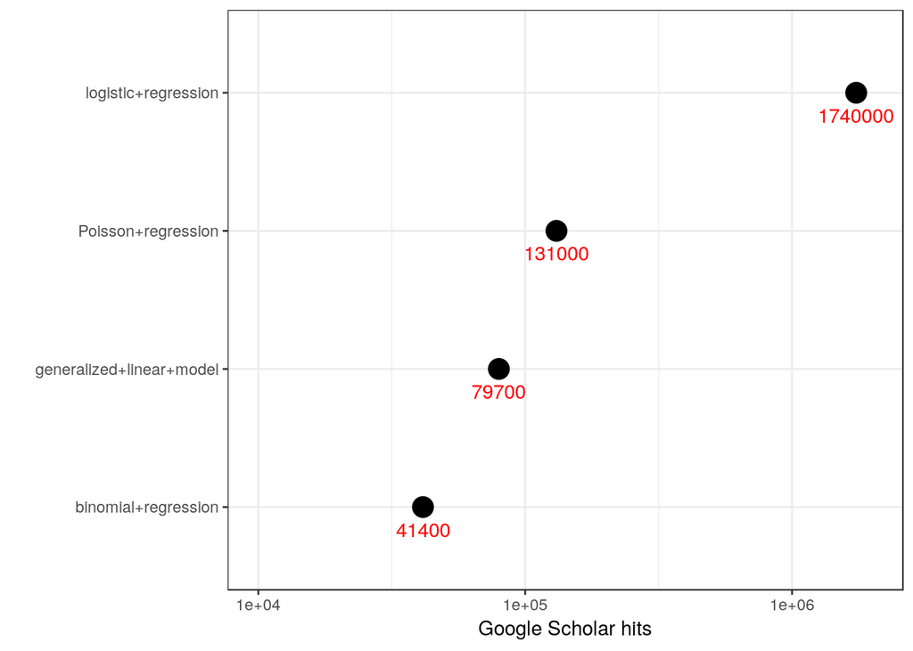

## Link functions

- on what scale are the data linear?
- link function goes from *data scale* (bounded) to *effect scale* (unbounded)
  - Poisson=log; binomial=logit
- *inverse link* function goes from effect scale to data scale
  - Poisson=exponential; binomial=logistic
- each family has a default “canonical” link (sensible + nice math)
  - default usually OK (except: use `family=Gamma(link="log")`)
  - probit vs. logit link for binomial family; mostly cultural

## Machinery

- “linear predictor” $\eta = \beta_0 + \beta_1 x_1 + \ldots$ describes patterns on the link (effect) scale
- Fit doesn’t transform the responses: instead applies *inverse* link function to the linear predictor
  - instead of $\log(y) \sim x$, we analyze $y \sim \mathrm{Poisson}(\exp(x))$
- this is good, because the observed value of $y$ might be zero
  - e.g. count (Poisson) phenotype vs. temperature (centered at 20 C)
  - with $\beta=\{1,1\}$, $T=15$, $\textrm{counts} \sim \textrm{Poisson}(\lambda=\exp(-4)=0.018)$

## Machinery (2)

Model setup is the same as linear models

- categorical vs. continuous predictors
- contrasts
- multivariable regression vs ANOVA vs ANCOVA vs …

but fit on the linear predictor (effect, link) scale

## logit/logistic function (`qlogis`/`plogis`)

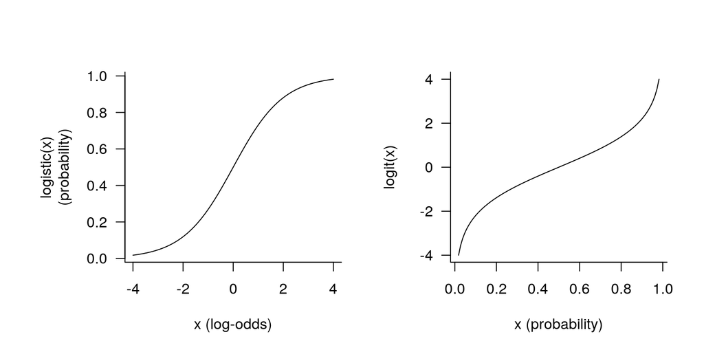

## overdispersion

- too much variance: (residual deviance)/(residual df) should be $\approx 1$. (Ratio >1.2 worrisome; ratio>3, v. worrisome (check your model & data!)
- quasi-likelihood models (e.g. `family=quasipoisson`); fit, then adjust CIs/p-values
- negative binomial etc.
- alternatives:
  - Poisson $\to$ negative binomial (`MASS::glm.nb`)
  - binomial $\to$ beta-binomial (`glmmTMB` package)
- overdispersion **not relevant** for
  - binary responses
  - families with estimated scale parameters (Gaussian, Gamma, NB, …)

## parameter interpretation

- as with linear models (change in response per change in input)
- but on *effect* scale
- log link: proportional for small $\beta$, changes
  - e.g. $\beta=0.01 \to$ “$\approx$ 1% change per unit change in input”
  - $\beta=3 \to$ “$(e^3)$=20-fold change per change in input”
- logit link: **depends on baseline probability**
  - low baseline prob: like log link
  - high baseline prob: prop. change in (1-prob)
  - medium prob: absolute change $\approx \beta/4$
  - e.g. $\beta_0=0$, $\beta_1=1$; estimated $\Delta$ prob $\approx$ 0.25 - `plogis(0)=` 0.5 - `plogis(0+1)=` 0.73
- also see [UCLA FAQ on odds ratios](https://stats.idre.ucla.edu/other/mult-pkg/faq/general/faq-how-do-i-interpret-odds-ratios-in-logistic-regression/); [here](http://www.mypolyuweb.hk/~sjpolit/logisticregression.html); read Gelman and Hill’s *Applied Regression Modeling* book (p. 81; [Google books link](https://books.google.ca/books?id=lV3DIdV0F9AC&printsec=frontcover&dq=gelman+hill+logistic+parameter&hl=en&sa=X&ved=0ahUKEwjt8Zq_1-bgAhUqzIMKHTl0D3EQ6AEIKjAA#v=snippet&q=divide%20by%204&f=false))

## inference

- Wald $Z$ tests (i.e., results of `summary()`), confidence intervals
  - approximate, can be way off if parameters have extreme values (*Hauck-Donner effect*/*complete separation*)
  - asymptotic (finite-size correction/“degrees of freedom” are hard, usually ignored)
- likelihood ratio tests (equivalent to $F$ tests); `drop1(model,test="Chisq")`, `anova(model1,model2)`), profile confidence intervals (`MASS::confint.glm`)
- AIC

## Model procedures

- formula similar to `lm` (but specifies relationship on linear predictor scale)
- specify family; maybe specify link
- always do Poisson, binomial regression on *counts*, never proportions (although can specify response as a proportion if you also give $N$ as the `weights` argument)
- Use *offsets* to address unequal sampling
- **always check for overdispersion** *unless* (1) already using quasilikelihood or (2) using binary data
- if you want to quote values on the original scale, confidence intervals need to be back-transformed; *never back-transform standard errors alone*

## binomial models

- for Poisson, Bernoulli (0/1) responses we only need one piece of information
- how do we specify denominator ($N$ in $k/N$)?
- traditional R: response is two-column matrix `cbind(successes,failures)` [**not** `cbind(successes,total)`]
- also allowed: response is proportion ($k/N$), also specify `weights=N`
- if equal for all cases and specified on the fly need to replicate:  
  `glm(p~...,data,weights=rep(N,nrow(data)))`

## offsets

- constant terms added to a model
- what if we want to model densities rather than counts?
- log-link (Poisson/NB) models: $\mu_0 = \exp(\beta_0 + \beta_1 x_1 + ...)$
- if we know the area then we want $\mu = A \cdot \mu_0$
- equivalent to adding $\log(A)$ to the linear predictor ($\exp(\log(\mu_0) + \log(A)) = \mu_0 \cdot A$)
- use `... + offset(log(A))` in R formula
- for survival/event modeling over different periods of time, a similar offset trick works with `link="cloglog"` (see [here](https://stats.stackexchange.com/questions/148699/modelling-a-binary-outcome-when-census-interval-varies))

## add-on packages

- `ggplot2`
  - `geom_smooth(method="glm", method.args=list(family=...))`
- `dotwhisker`, `emmeans`, `effects` all work
  - need to interpret parameters appropriately
  - means may be computed on link *or* response scale

## Advanced topics

- complete separation
- ordinal data
- zero-inflation
- non-standard link functions
- visualization (hard because of overlaps: try `stat_sum`, `position="jitter"`, `geom_dotplot`, ([beeswarm plot](http://stackoverflow.com/questions/11889353/avoiding-overlap-when-jittering-points%20beeswarm%20plot%5D))
- see also: GLM extensions talk ([source](https://github.com/bbolker/iiscvisit/blob/master/workshops/glm_extensions.rmd), html)

## Common(est?) `glm()` problems

- neglecting overdispersion
- binomial/Poisson models with non-integer data
- equating negative binomial with binomial rather than Poisson
- failing to specify `family` ($\to$ linear model); using `glm()` for linear models (unnecessary)
- predictions on effect scale
- using $(k,N)$ rather than $(k,N-k)$ in binomial models
- worrying about overdispersion unnecessarily (binary/Gamma)
- back-transforming SEs rather than CIs
- ignoring random effects
- Poisson for *underdispersed* responses

# Example

## AIDS (Australia: Dobson & Barnett)

```r
aids <- read.csv("aids.csv")
aids <- transform(aids, date=year+(quarter-1)/4)
gg0 <- ggplot(aids,aes(date,cases))+geom_point()
```

## Easy GLMs with ggplot

```r
gg1 <- gg0 + geom_smooth(method="glm",colour="red",
                         method.args=list(family="quasipoisson"))
```

## Equivalent code

```r
g1 <- glm(cases~date,aids,family=quasipoisson(link="log"))
summary(g1)
```

[output not shown]

## Diagnostics (`plot(g1)`)

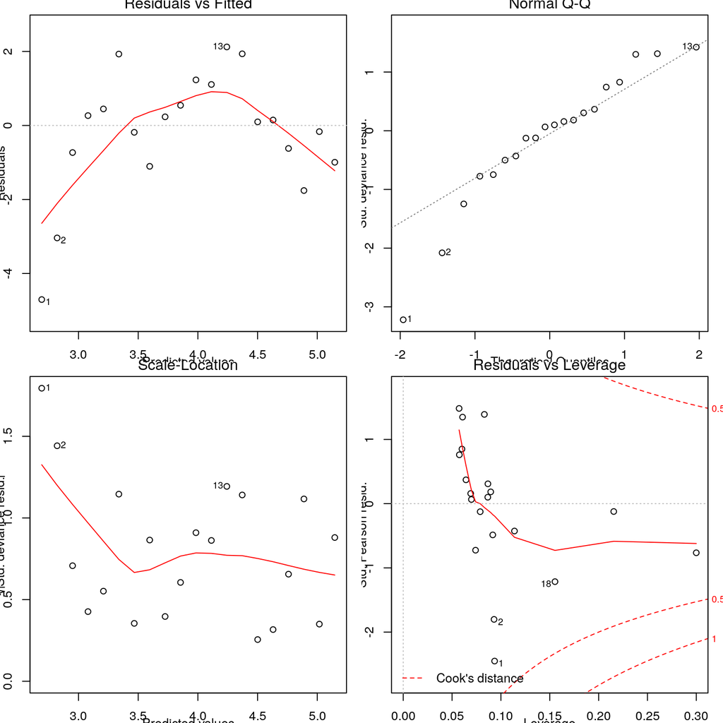

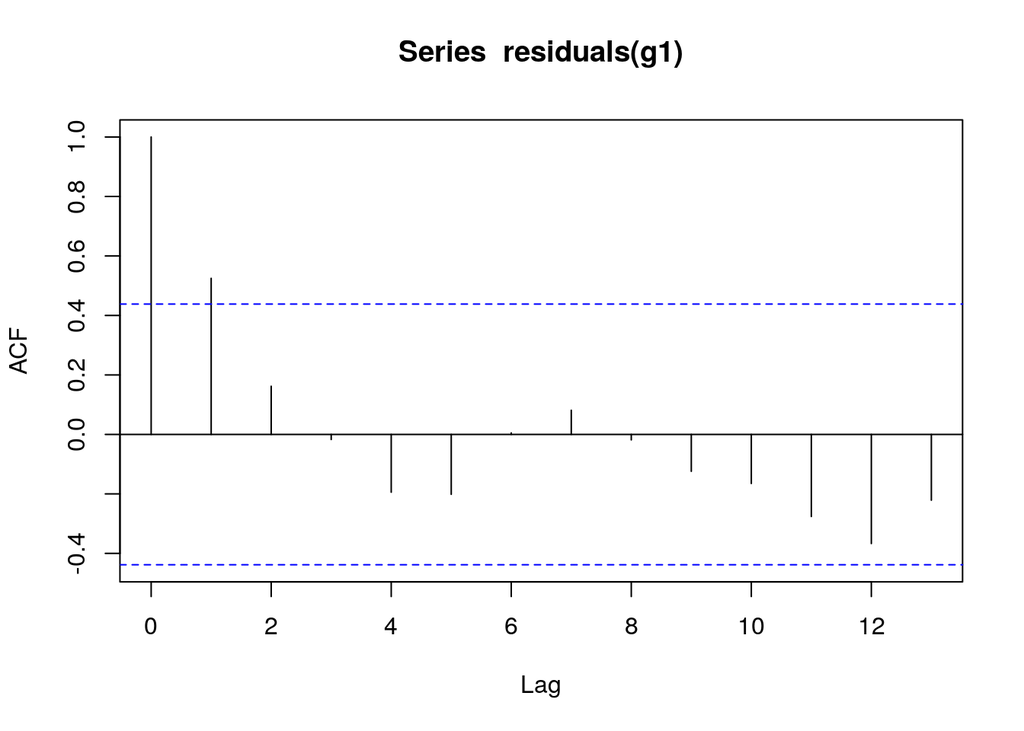

```r
acf(residuals(g1)) ## check autocorrelation
```

## ggplot: check out quadratic model

```r
gg2 <- gg1+geom_smooth(method="glm",formula=y~poly(x,2),
                       method.args=list(family="quasipoisson"))
```

## on log scale

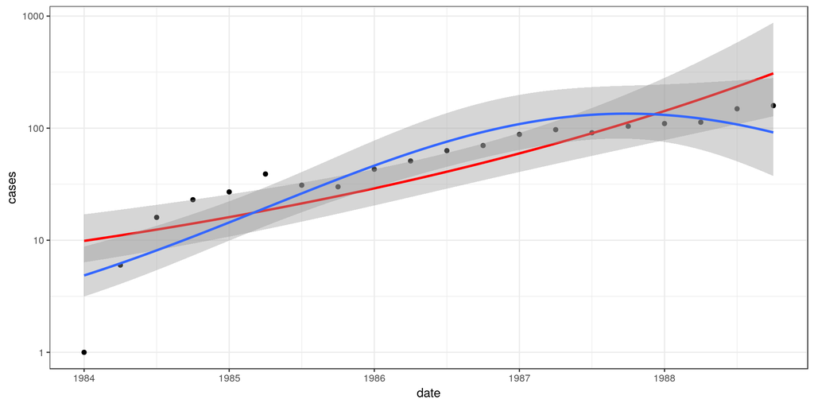

```r
gg2+scale_y_log10()
```

## improved model

```r
g2 <- update(g1,.~poly(date,2))
summary(g2)
```

```
##
## Call:
## glm(formula = cases ~ poly(date, 2), family = quasipoisson(link = "log"),
##     data = aids)
##
## Deviance Residuals:
##     Min       1Q   Median       3Q      Max
## -3.3290  -0.9071  -0.0761   0.8985   2.3209
##
## Coefficients:
##                Estimate Std. Error t value Pr(>|t|)
## (Intercept)     3.86859    0.05004  77.311  < 2e-16 ***
## poly(date, 2)1  3.82934    0.25162  15.219 2.46e-11 ***
## poly(date, 2)2 -0.68335    0.19716  -3.466  0.00295 **
## ---
## Signif. codes:  0 '***' 0.001 '**' 0.01 '*' 0.05 '.' 0.1 ' ' 1
##
## (Dispersion parameter for quasipoisson family taken to be 1.657309)
##
##     Null deviance: 677.264  on 19  degrees of freedom
## Residual deviance:  31.992  on 17  degrees of freedom
## AIC: NA
##
## Number of Fisher Scoring iterations: 4
```

```r
anova(g1,g2,test="F") ## for quasi-models specifically
```

```
## Analysis of Deviance Table
##
## Model 1: cases ~ date
## Model 2: cases ~ poly(date, 2)
##   Resid. Df Resid. Dev Df Deviance      F   Pr(>F)
## 1        18     53.020
## 2        17     31.992  1   21.028 12.688 0.002399 **
## ---
## Signif. codes:  0 '***' 0.001 '**' 0.01 '*' 0.05 '.' 0.1 ' ' 1
```

## new diagnostics

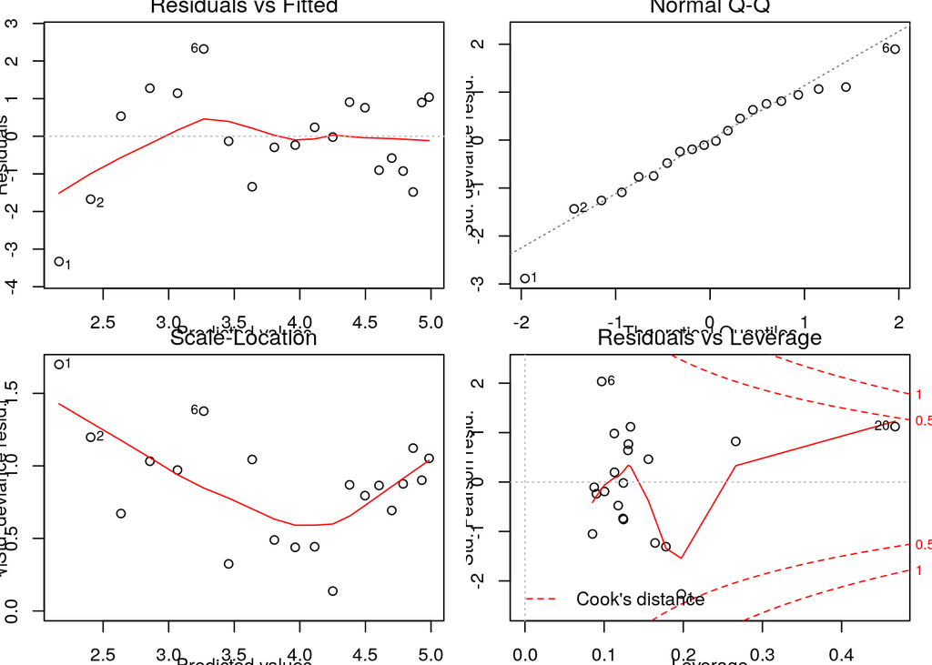

## autocorrelation function

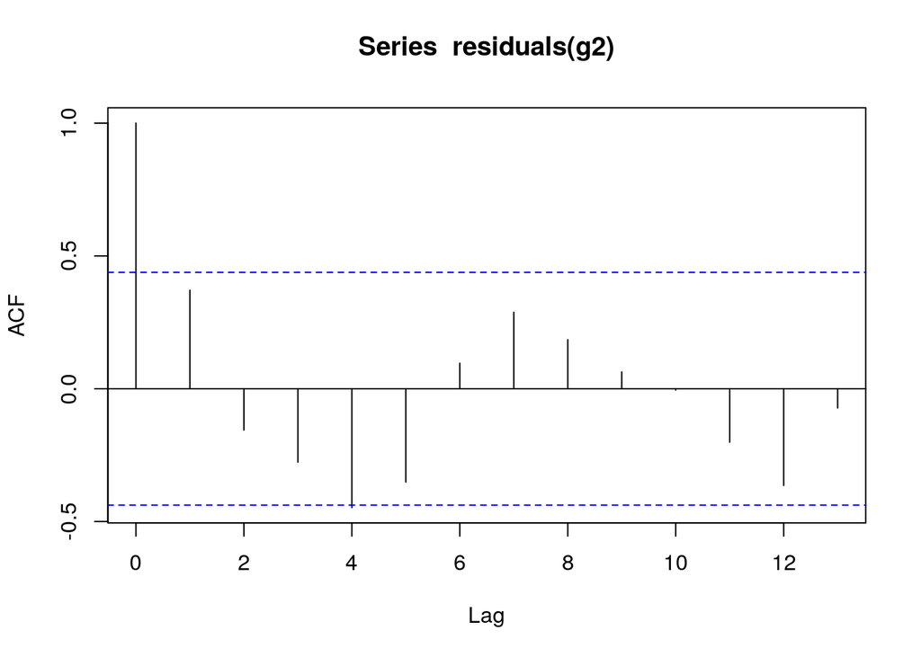

```r
acf(residuals(g2)) ## check autocorrelation
```